# Practice Script for Transportation Exercise

C. Bae

October 2023

## Context for Lab Exercise

### Background and Related Sources

There are various aspects of transportation data analysis that can help us understand patterns of daily mobility in urban contexts. We can look at factors around station coverage, accessibility to stations, and regular movement behavior based on public open data provided by micro-mobility and other shared mobility operators (such as bikeshare systems). Another useful source of information is the [Chicago Transportation Network Providers](https://www.chicago.gov/city/en/depts/bacp/provdrs/vehic/svcs/tnp.html) data, which has information on the usage of ride-hailing services such as Lyft and Uber.

Another good resource for spatial analysis in the transportation context is [Chapter 13: Transportation](https://geocompr.robinlovelace.net/transport.html) from Lovelace’s *Geocomputation with R* (2023), which explores in-depth a transportation case study of Bristol to ask how to increase cycling within the city. As stated in that chapter, you may want to explore these aspects of transportation research:

- Describe the geographical patterns of transport behavior in cities
- Identify key public transport nodes supporting multi-mode trips
- Analyze travel ‘desire lines’ to find where many people drive short distances
- Identify cycle route locations that will encourage less car driving and more cycling

### Divvy Bikeshare System Data

For our exercise today and this week’s assignment, we’ll use open data from Chicago’s bikeshare system, Divvy.

Data source: [Divvy Data](https://divvybikes.com/system-data)

Metadata:

> Each trip is anonymized and includes:
> - Trip start day and time
> - Trip end day and time
> - Trip start station
> - Trip end station
> - Rider type (Member, Single Ride, and Day Pass)

> The data has been processed to remove trips that are taken by staff as they service and inspect the system; and any trips that were below 60 seconds in length (potentially false starts or users trying to re-dock a bike to ensure it was secure).

Although here we work only with trips data source, you are welcome to additionally use the [Divvy station data](https://data.cityofchicago.org/Transportation/Divvy-Bicycle-Stations-In-Service/67g3-8ig8) (last updated September 2022) from the Chicago Open Data Portal or more updated data from the JSON-feed (API), [Chicago bike routes](https://data.cityofchicago.org/Transportation/Bike-Routes/3w5d-sru8) spatial data, and/or other sources you locate.

## Set-up

### Load libraries

```r
library(tidyverse)  # dplyr, tidyr
library(sf)         # for R spatial data format
library(tmap)       # for spatial visualization

# New libraries since last
library(stplanr)    # for processing geographic transport data

# Additional optional packages
#library(osmdata)
#library(sfnetworks) # spatial network classes and functions
```

### Import Divvy data from Chicago Open Data Portal

Specifically, we use data downloaded as a CSV for one month of trips taken using the Divvy bikeshare system for the month of June 2023.

```r
divvy_data <- read.csv("data/202306-divvy-tripdata.csv")

# inspect dimensions and structure
dim(divvy_data)
```

```
## [1] 719618     13
```

```r
str(divvy_data)
```

```
## 'data.frame':    719618 obs. of  13 variables:
##  $ ride_id           : chr  "6F1682AC40EB6F71" "622A1686D64948EB" "3C88859D926253B4" "EAD8A5E0259DEC88" ...
##  $ rideable_type     : chr  "electric_bike" "electric_bike" "electric_bike" "electric_bike" ...
##  $ started_at        : chr  "2023-06-05 13:34:12" "2023-06-05 01:30:22" "2023-06-20 18:15:49" "2023-06-19 14:56:00" ...
##  $ ended_at          : chr  "2023-06-05 14:31:56" "2023-06-05 01:33:06" "2023-06-20 18:32:05" "2023-06-19 15:00:35" ...
##  $ start_station_name: chr  "" "" "" "" ...
##  $ start_station_id  : chr  "" "" "" "" ...
##  $ end_station_name  : chr  "" "" "" "" ...
##  $ end_station_id    : chr  "" "" "" "" ...
##  $ start_lat         : num  41.9 41.9 42 42 42 ...
##  $ start_lng         : num  -87.7 -87.7 -87.7 -87.7 -87.7 ...
##  $ end_lat           : num  41.9 41.9 41.9 42 42 ...
##  $ end_lng           : num  -87.7 -87.7 -87.6 -87.7 -87.7 ...
##  $ member_casual     : chr  "member" "member" "member" "member" ...
```

```r
head(divvy_data)
```

```
##            ride_id rideable_type          started_at            ended_at
## 1 6F1682AC40EB6F71 electric_bike 2023-06-05 13:34:12 2023-06-05 14:31:56
## 2 622A1686D64948EB electric_bike 2023-06-05 01:30:22 2023-06-05 01:33:06
## 3 3C88859D926253B4 electric_bike 2023-06-20 18:15:49 2023-06-20 18:32:05
## 4 EAD8A5E0259DEC88 electric_bike 2023-06-19 14:56:00 2023-06-19 15:00:35
## 5 5A36F21930D6A55C electric_bike 2023-06-19 15:03:34 2023-06-19 15:07:16
## 6 CF682EA7D0F961DB electric_bike 2023-06-09 21:30:25 2023-06-09 21:49:52
##   start_station_name start_station_id end_station_name end_station_id start_lat
## 1                                                                         41.91
## 2                                                                         41.94
## 3                                                                         41.95
## 4                                                                         41.99
## 5                                                                         41.98
## 6                                                                         41.99
##   start_lng end_lat end_lng member_casual
## 1    -87.69   41.91  -87.70        member
## 2    -87.65   41.94  -87.65        member
## 3    -87.68   41.92  -87.63        member
## 4    -87.65   41.98  -87.66        member
## 5    -87.66   41.99  -87.65        member
## 6    -87.68   41.94  -87.65        member
```

```r
# replace blanks with NA (null) values
divvy_data <- divvy_data %>% mutate_if(is.character, ~na_if(., ''))
```

### Create spatial objects for Origin and Destination bikeshare stations

First, we’ll create a dataframe representing the origin stations of interest, which we can convert to spatial format. Originally I did this rather than joining to another dataset of bikeshare stations because the latitude and longitude coordinates are already given within this dataset.

Also note that we have some rides that begin and/or end outside of a docked station (those whose start_station and/or end_station are missing). For those, a general location is also given, which you can see by the longitude and latitude decimal degrees rounded up to two decimal places - this represents an accuracy of up to about 1km. See this [GIS wiki article](http://wiki.gis.com/wiki/index.php/Decimal_degrees) for more context. In this exercise we choose to drop those using the `drop_na()` function.

```r
# Keep only one instance of each origin station to create point dataset of stations (note minor noise in lat/long)
o_stations <- divvy_data %>%
  drop_na(start_station_id) %>% # remove rows where start_station_id has null values
  distinct(start_station_id, .keep_all = TRUE)

# Drop columns that aren't relevant (because they pertain to individual rides)
colnames(o_stations)
```

```
##  [1] "ride_id"            "rideable_type"      "started_at"
##  [4] "ended_at"           "start_station_name" "start_station_id"
##  [7] "end_station_name"   "end_station_id"     "start_lat"
## [10] "start_lng"          "end_lat"            "end_lng"
## [13] "member_casual"
```

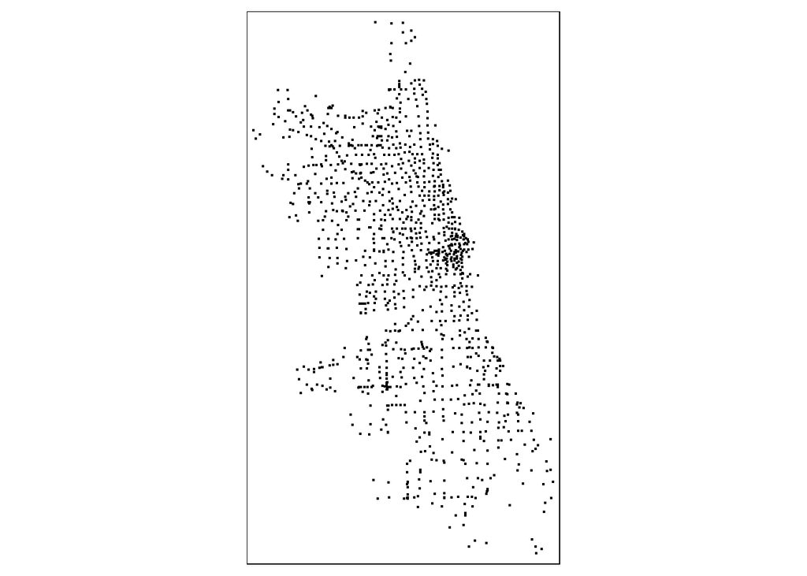

```r
o_stations <- o_stations %>%
  subset(select=c("start_station_name", "start_station_id", "start_lat", "start_lng"))

# Convert to spatial using start_lat, start_long
o_spatial <- o_stations %>%
  st_as_sf(coords=c("start_lng", "start_lat"), crs = 4326) # x = longitude, y = latitude

# Plot these locations as points to visually check for outliers or potential issues
tm_shape(o_spatial) + tm_dots()
```

Repeat the above for destination stations. Remember in this case we drop start station information and only retain end station information.

```r
d_stations <- divvy_data %>%
  drop_na(end_station_id) %>%
  distinct(end_station_id, .keep_all = TRUE)

d_spatial <- d_stations %>%
  subset(select=c("end_station_name", "end_station_id", "end_lat", "end_lng")) %>%
  st_as_sf(coords=c("end_lng","end_lat"), crs = 4326)
```

*Note*: We will see later in the exercise that we need to transform the CRS of the Divvy data for use with our projected Community Areas boundary shapefiles. For an in-depth resource on Coordinate Reference Systems (CRS), see this section from Lovelace’s *Geocomputation with R*: https://bookdown.org/robinlovelace/geocompr/reproj-geo-data.html

## Subset rides data

You may need to work with a subset of your original dataset, such as in the case of very large data, and generally because not all observations or variables will be of interest to your question. Our original Divvy rides dataset is reasonably large at 719618 rows by 13 columns, but should be manageable in R.

```r
# Create subset of a random sample of 500 rows
subset1 <- slice_sample(divvy_data, n = 500)

# Use unique() to see what values exist for a certain categorical column
unique(divvy_data$rideable_type)
```

```
## [1] "electric_bike" "classic_bike"  "docked_bike"
```

```r
# Subset based on condition using filter()
#subset2 <- filter(divvy_data, rideable_type == "electric_bike")
subset2 <- divvy_data %>% filter(rideable_type == "electric_bike")
```

### Example question: Where do most riders go from the Divvy station at Cornell Ave & Hyde Park Blvd?

First, we will subset just those rides starting from Cornell Ave & Hyde Park Blvd based on `start_station_id`.

*Note*: You can search in RStudio ‘View’ to identify the relevant station ID.

```r
subset3 <- divvy_data %>% filter(start_station_id == "KA1503000007")

# Make table of destinations, arranged in order from highest number of riders
hp_stop <- subset3 %>%
  group_by(end_station_name) %>%
  summarize(count = n()) %>%
  arrange(desc(count))

head(hp_stop)
```

```
## # A tibble: 6 × 2
##   end_station_name             count
##   <chr>                        <int>
## 1 Cornell Ave & Hyde Park Blvd   122
## 2 University Ave & 57th St       104
## 3 <NA>                            89
## 4 Kimbark Ave & 53rd St           67
## 5 Woodlawn Ave & 55th St          46
## 6 Ellis Ave & 55th St             42
```

```r
# Join to spatial destination object
joined_hp_stop <- merge(d_spatial, hp_stop)
```

You should now see that the new object has both spatial location and counts.

Let’s plot those destination stations alongside (‘on top of’) our origin station.

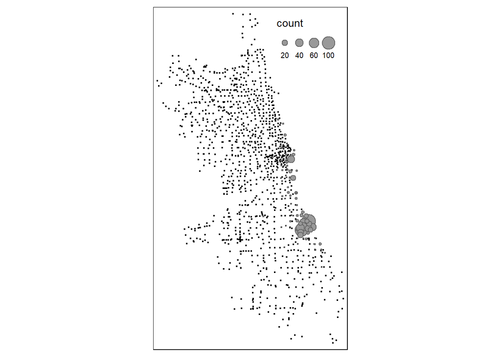

```r
tm_shape(o_spatial) + tm_dots() +
  tm_shape(joined_hp_stop) + tm_bubbles(size = "count")
```

```r
# Explore in interactive map
tmap_mode("view")

# View in static map
#tmap_mode("plot")

# Or just switch modes
ttm()
```

## Zonal Summaries

You may be interested in more than one ‘origin’ or ‘destination’ Divvy station, however. Let’s next summarize our monthly data based on travel zones. In this case, our Chicago Community Areas will serve as a nice areal unit for our analysis.

### Example question: What are the most common trips (or destination zones) that originate from Hyde Park Divvy stations?

Workflow idea:

- Identify which stations are located within the Hyde Park Community Area
- Subset data based on those stations only
- Plot flows based on volume

This one is very similar to O-D analyses we did in last week’s exercise.

### Read in Community Areas shapefile

```r
CAs <- st_read("data\\CommAreas.shp") # make sure data is unzipped; unlike QGIS, sf doesn't recognize .zip files
# Look at the Community Area boundaries
#tm_shape(CAs) + tm_polygons()
```

### Select the Hyde Park Community Area

We can use the origin points object we’ve already created above, which is named `o_spatial` and is an sf object.

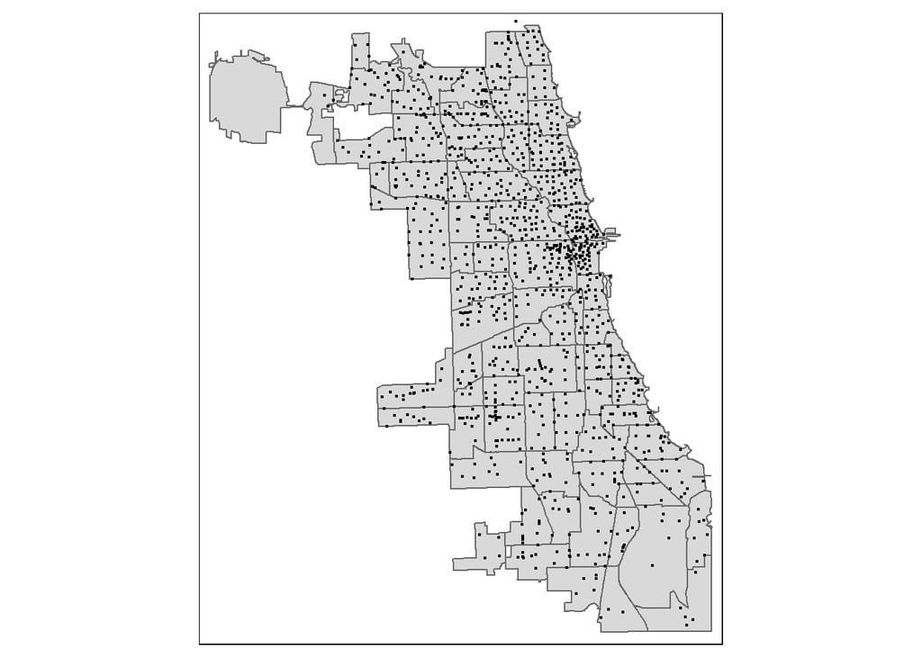

```r
# Look at the Community Area boundaries and the origin stations
tm_shape(CAs) + tm_polygons() +
  tm_shape(o_spatial) + tm_dots()
```

To select just the origin stations that are located in Hyde Park, we use a point-in-polygon operation. We first join the two datasets using the `st_join()` function. We want to find the stations that are within the Community Areas, so specify the datasets in that order and use `st_within` as the method of join.

This will output a new sf object which has the original rows for each listing appended with the Community Area information. The output will have the same number of rows as the original point dataset.

```r
#pip_stations <- st_join(o_spatial, CAs, join = st_within)

# The above line doesn't work because CRS are not equal
#st_crs(o_spatial)
#st_crs(CAs)

# Transform CRS from points to match Community Areas
o_spatial <- st_transform(o_spatial, 3435)

# Try again
pip_stations <- st_join(o_spatial, CAs, join = st_within)
head(pip_stations)
```

```
## Simple feature collection with 6 features and 11 fields
## Geometry type: POINT
## Dimension:     XY
## Bounding box:  xmin: 1147373 ymin: 1871655 xmax: 1182390 ymax: 1922494
## Projected CRS: NAD83 / Illinois East (ftUS)
##               start_station_name start_station_id AREA PERIMETER COMAREA_
## 1          Wood St & Chicago Ave              637    0         0        0
## 2   California Ave & Division St            13256    0         0        0
## 3           Kenosha & Wellington              361    0         0        0
## 4 California Ave & Milwaukee Ave            13084    0         0        0
## 5    Cottage Grove Ave & 51st St     TA1309000067    0         0        0
## 6        Western Ave & Roscoe St            15634    0         0        0
##   COMAREA_ID AREA_NUMBE       COMMUNITY AREA_NUM_1 SHAPE_AREA SHAPE_LEN
## 1          0         24       WEST TOWN         24  127562905  55203.72
## 2          0         24       WEST TOWN         24  127562905  55203.72
## 3          0         20         HERMOSA         20   32602059  27179.02
## 4          0         22    LOGAN SQUARE         22  100057567  49213.42
## 5          0         38 GRAND BOULEVARD         38   48492503  28196.84
## 6          0          5    NORTH CENTER          5   57054168  31391.67
##                  geometry
## 1 POINT (1164268 1905240)
## 2 POINT (1157351 1907894)
## 3 POINT (1147373 1919279)
## 4 POINT (1157363 1915069)
## 5 POINT (1182390 1871655)
## 6 POINT (1160010 1922494)
```

Now, each station has the associated Community Area information joined to it. We can count how many stations are within each Community Area, then join that back to the Community Areas object so we can plot it on the map.

```r
stations_per_CA <- count(as_tibble(pip_stations), COMMUNITY) %>%
  print(head(10))
```

```
## # A
## #   tibble:
## #   78 ×
## #   2
##    COMMU…¹
##    <chr>
##  1 ALBANY…
##  2 ARCHER…
##  3 ARMOUR…
##  4 ASHBURN
##  5 AUBURN…
##  6 AUSTIN
##  7 AVALON…
##  8 AVONDA…
##  9 BELMON…
## 10 BEVERLY
## # … with
## #   68
## #   more
## #   rows,
## #   1
## #   more
## #   variable: …
```

```r
CAs_with_stations <- left_join(CAs, stations_per_CA)
```

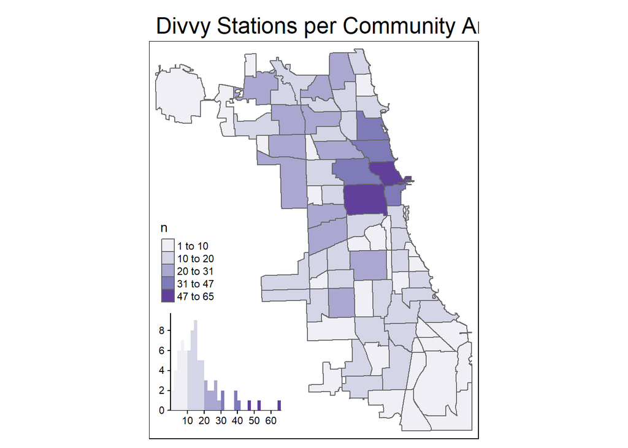

```r
# Plot Community Areas, creating a choropleth based on origins_per_CA counts
tm_shape(CAs_with_stations) + tm_polygons("n", style = "jenks", palette = "Purples", legend.hist = TRUE) +
  tm_layout(main.title = "Divvy Stations per Community Area")
```

But let’s take a step back and select just the stations in Hyde Park based on the `COMMUNITY` variable.

```r
hp_stations <- pip_stations %>%
  filter(COMMUNITY == "HYDE PARK")

# uncomment if you want to check:
# tm_shape(CAs) + tm_polygons() +
#   tm_shape(hp_stations) + tm_dots()
```

### Subset trips that originate in Hyde Park

We can then subset our trips data based on the IDs of the Hyde Park stations.

```r
hp_starts <- divvy_data %>%
      filter(start_station_id %in% hp_stations$start_station_id)
```

Note that by subsetting our trips data based on those that began in the Hyde Park Divvy stations, we are ignoring any potential trips that began in Hyde Park outside of a docked station (such as in the case of dockless bikes).

For zonal summaries we will want to return to exploring the familiar concept of origin-destination flows.

### Origin-destination flows (now in R!)

Likely you’ll subset your trips data before this; the example given below is if we want to consider only those trips originating from a Hyde Park (docked) Divvy station.

Based on station names we can look at overall flow of trips going from Hyde Park Community Area stations to stations in other Community Areas.

```r
# drop_na for end_stations_name
hp_starts <- hp_starts %>%
  drop_na(end_station_id)

hp_trip_summary <- hp_starts %>%
  group_by(start_station_name, end_station_name) %>%
  summarise(flow = n())
# this function is from stplanr package
#flows_from_hp <- od2line(flow = hp_trip_summary, zones = o_spatial)

# above doesn't work, so manually drop rows
hp_trip_summary <- hp_trip_summary[-c(356, 518, 524, 651, 815), ]

# then try again
flows_from_hp <- od2line(flow = hp_trip_summary, zones = o_spatial)
```

…this method of manually dropping rows is dangerous, but package doesn’t seem to have built-in option for identifying offending rows, as far as I can tell. You can alternatively remove stations by name in the `end_station_name` column.

Removed stations:

- Row 356: Public Rack - Saginaw Ave & 93rd St
- Row 518: Western Blvd & 48th Pl
- Row 524: Buckingham Fountain
- Row 651: Buckingham Fountain
- Row 815: Buckingham Fountain

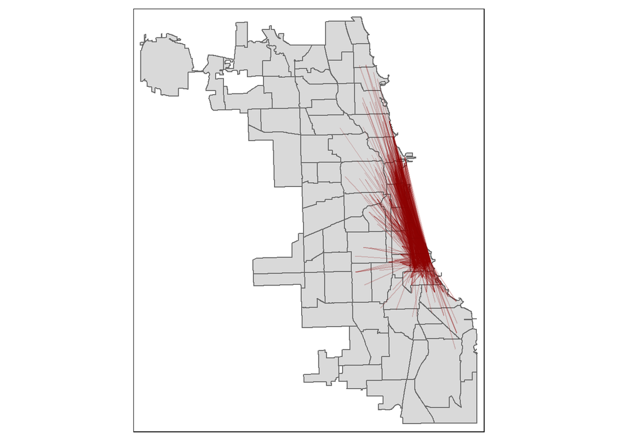

```r
tm_shape(CAs) + tm_polygons() +
  tm_shape(flows_from_hp) + tm_lines(col = "darkred", alpha = 0.2)
```

```r
  # tm_shape(flows_from_hp) + tm_lines(col = "flow", palette = "Reds")
```

This flow map is difficult to interpret for a number of reasons.

## Appendix: Bonus Additional Ideas

### Street Network Data Acquisition from OpenStreetMap (OSM)

Another idea is to consider the underlying street network, either for comparing structures of the road and cycling path network or for inferring commonly used routes between sets of origins and destinations.

We can first use a boundary of all of Chicago, downloaded through the **osmdata** package using a bounding box command `getbb` which can return a bounding box or a polygon boundary. This returned result may not match the ‘official’ boundary. It only needs to be good enough to spatially select the area (really just a bounding box containing the area) for which we want to download features.

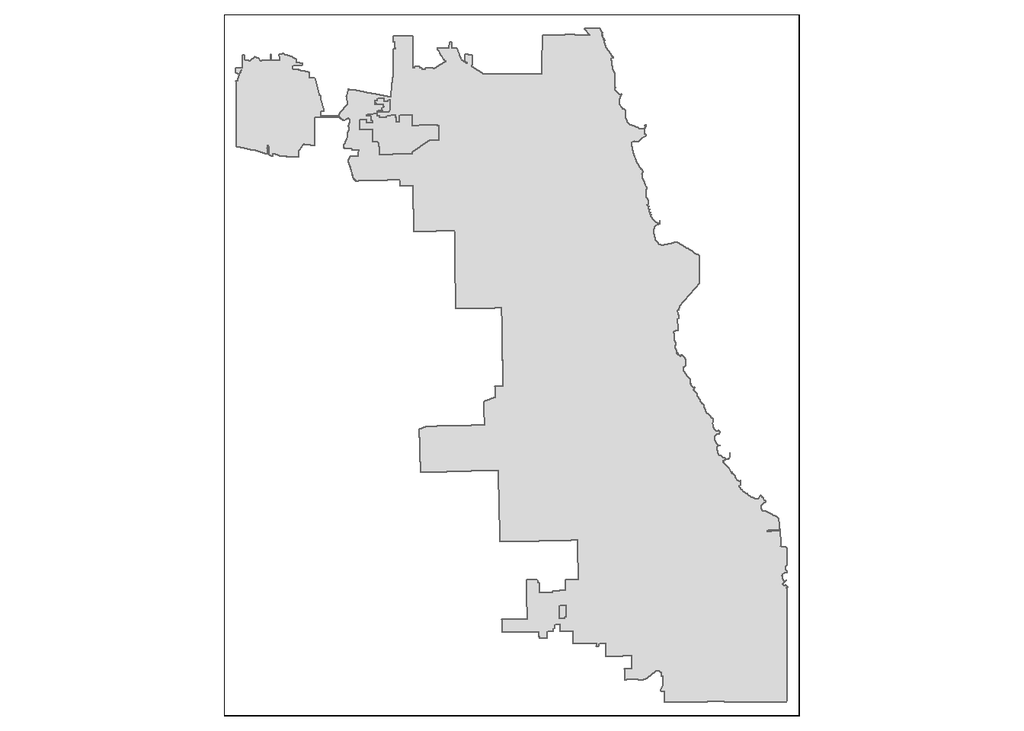

```r
#install.packages("osmdata")

library(osmdata)
chi <- osmdata::getbb("Chicago", format_out = "sf_polygon", limit = 1)

tm_shape(chi) + tm_polygons()
```

We are interested in OSM features with the high-level key “highway”. See the [OpenStreetMap wiki entry](https://wiki.openstreetmap.org/wiki/Key:highway) for more detail. We will first see what tags are available for the “highway” key.

```r
highway_tags <- available_tags("highway") # you can try other tags as well, such as "amenity"
```

Hint: Use “Query Features” in the OSM web interface to see what tags are used for the kind of features you’re interested in.

Let’s extract some features now.

```r
cyclepaths <- getbb("Chicago") %>%
  opq() %>%
  add_osm_feature(key = "highway",
                  value = c("cycleway")) %>%
  osmdata_sf() # in sf (spatial) format

bikeroutes <- getbb("Chicago") %>%
  opq() %>%
  add_osm_feature(key = "route",
                  value = c("bicycle")) %>%
  osmdata_sf() # in sf (spatial) format
```

Other potential tags of interest may be “footpath”, “secondary”, “tertiary”, “residential”, etc.

Our new object from osmdata is a collection of dataframes which can be viewed or mapped easily.

```r
# look at how the data is organized
head(cyclepaths[["osm_lines"]])
```

```
## Simple feature collection with 6 features and 84 fields
## Geometry type: LINESTRING
## Dimension:     XY
## Bounding box:  xmin: -87.65395 ymin: 41.85753 xmax: -87.61813 ymax: 41.98628
## Geodetic CRS:  WGS 84
##            osm_id            name abandoned:name abandoned:operator
## 5950860   5950860            <NA>           <NA>               <NA>
## 23852382 23852382 Lakefront Trail           <NA>               <NA>
## 23924363 23924363            <NA>           <NA>               <NA>
## 23946786 23946786            <NA>           <NA>               <NA>
## 23987404 23987404            <NA>           <NA>               <NA>
## 23998804 23998804 Lakefront Trail           <NA>               <NA>
##          abandoned:railway access alt_name    bicycle bridge bridge:movable
## 5950860               <NA>   <NA>     <NA> designated   <NA>           <NA>
## 23852382              <NA>   <NA>     <NA> designated    yes           <NA>
```

[output cut: 102 more lines]

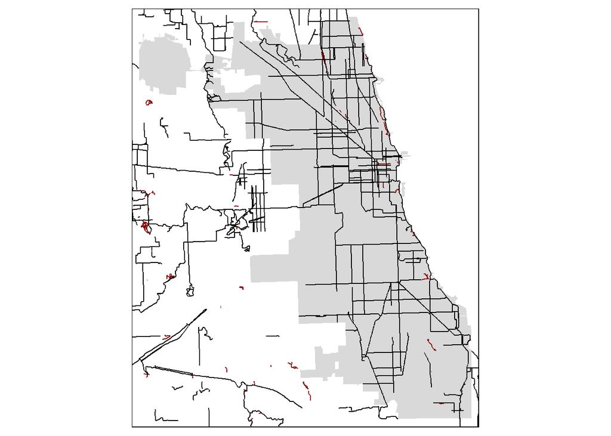

```r
tm_shape(CAs) + tm_fill() +
  tm_shape(cyclepaths$osm_lines) + tm_lines(col = "darkred") +
  tm_shape(bikeroutes$osm_lines) + tm_lines()
```

As you can see, you would want to compare this volunteer-contributed data and the selected tags for quality before using it as part of your analysis.

Further explore the documentation and other guides to the osmdata package to plan out a sample workflow for acquiring geographic data related to transportation (such as street networks, transit lines, etc). Which features are relevant to the question(s) you are asking?

### Shortest Path Routing from OSRM

#### Example question: What are key segments of the Chicago road network that can help improve connectivity for cyclists? How much does the current bicycle infrastructure support movement along the shortest routes for popular flows?

Workflow idea:

- Consider existing high-volume O-D segments (paired locations)
- Calculate shortest distance routes using city road network, making choices such as removing highways in that consideration
- For some cases, you may want to remove existing cycle infrastructure from your assessment, so we can consider only places of possible future improvement

From McKenzie & Romm reading: > “…trip distance was calculated along a city’s road network. The shortest path route between the origin and destination for each proposed trip were computed using the Open Source Routing Machine (http://project-osrm.org/) with routing set to shortest distance along the OpenStreetMap road network (including foot paths).”

For those interested in routing along street networks, see additional worked examples in the Lovelace [Section 13.6 Routes](https://r.geocompx.org/transport.html#routes) reading. There is discussion of different routing engines you can use, including the OSRM mentioned in the McKenzie & Romm reading. However, note that this is a more advanced process so it is just included here in case of interest.